# Moja Pasja: Wędkarstwo

Relaks, natura i trochę adrenaliny

Grzegorz Jaszczyszyn

## 1. Dlaczego to lubię?

Wędkarstwo to dla mnie coś więcej niż siedzenie nad wodą.

- **Reset głowy:** Po całym tygodniu nauki nic tak nie relaksuje jak cisza nad jeziorem.
- **Adrenalina:** Ten moment, kiedy spławik znika pod wodą albo czujesz uderzenie na wędce – bezcenne.
- **Natura:** Można zobaczyć rzeczy, których nie widać z perspektywy kanapy.

## 2. Co w ogóle łowię?

Nie jestem zawodowcem, łowię rekreacyjnie. Skupiam się na naszych polskich gatunkach:

1. **Karp:** Waleczna ryba, daje dużo frajdy przy holu.
2. **Szczupak:** Drapieżnik, trzeba go aktywnie szukać (spinning).
3. **Leszcz:** Najczęstsza zdobycz, idealna, żeby nie nudzić się nad wodą.

## 3. Statystyki z dziennika

Od trzech lat staram się zapisywać ciekawsze sztuki w notatniku.

Nie liczę “drobnicy” (małych rybek), tylko te wymiarowe sztuki, którymi można się pochwalić. Na następnym slajdzie przygotowałem wykres podsumowujący moje wyniki z lat 2021-2023.

## 4. Wykres moich połowów

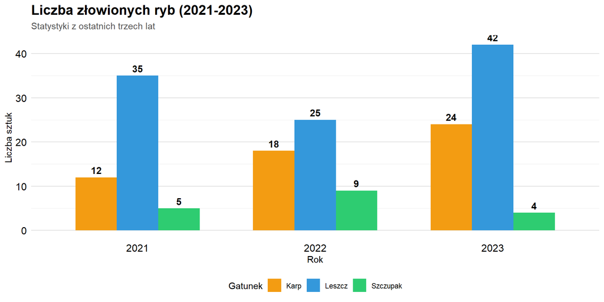

## 5. Analiza wyników

Co widać na wykresie?

- **Niebieskie słupki (Leszcz):** Tego łowię najwięcej, bo najłatwiej go złapać. W 2023 był rekordowy rok (42 sztuki).
- **Pomarańczowe (Karp):** Widać progres. W 2021 tylko 12 sztuk, a w 2023 już 24. Uczę się i mam lepsze efekty.
- **Zielone (Szczupak):** Z drapieżnikami jest najtrudniej, to rzadkie trofea, ale każda sztuka cieszy podwójnie.

## 6. Wielkie marzenie

Moim celem na przyszłość jest złowienie króla polskich wód – **Suma**.

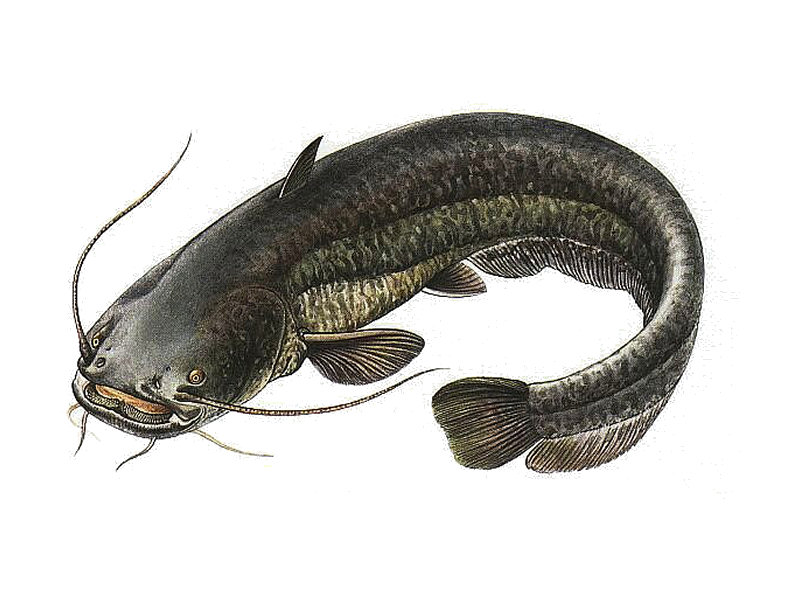

To ogromna i silna ryba. Mam nadzieję, że kiedyś uda mi się wyholować taką “bestię” powyżej 150 cm.

## 7. Podsumowanie

Wędkarstwo uczy cierpliwości i pokory. Czasem siedzi się 5 godzin i nic nie bierze, a czasem jest branie za braniem.